# Overview of *functClust*

Benoît Jaillard

2020-11-30

## Aim of functional clustering

An *interactive system* is here understood as a collection of *components* that interact when they co-occur, and whose interactions generate an emergent, collective, system-specific *performance*, function or property. When we subsample different components that belong to the system, we observe that different component *assemblages* generate different emergent, collective, system-specific performances. We thus assume that different values of performances are associated with different composition of component assemblages, that is to say with different co-occurring components.

The aim of functional clustering is to identify the role played by each component belonging to the system on the genesis of the emergent, collective, system-specific performance. For doing that, we need a collection of subsamples, *i.e.* sub-systems, of different elemental composition, *i.e.* different assemblages of components, of which emergent, collective, system-specific performances are observed.

A *functional clustering* groups the components of the interactive system on the basis of their effects on the system-specific performance. The effect on assemblage performance can be induce when the components occur alone or in combination with other components. The procedure groups first the components that induce similar effects on the performance when they co-occur with the same other components within the system: a functional group clusters together components that are functionally redundant for the performance in consideration.

We term *assembly motif* a combination of functional clusters, more precisely speaking a combination of components that belong to different functional clusters. Each assembly motif describes therefore a kind of component assemblage. We assume that each assembly motif is associated with a mean value of observed performances. Clustering components in functional groups generates a classification of component assemblages based on their assembly motif. We evaluate the quality of each component clustering by the coefficient of determination of the performance modelled by the classification of component assemblages. An iterative process then enables identifying the component clustering in functional groups that best accounts for the observed performance, *i.e.* that maximizes the coefficient of determination of the observed performance.

The combinatorial approach therefore generates a tree that groups functionally redundant components of the system for the system-specific performance in consideration. It is a functional clustering of components that belong to the interactive system for the performance in consideration.

## Method for clustering functionally redundant components of an interactive system

The functional clustering of components belonging to an interactive system works in three steps:

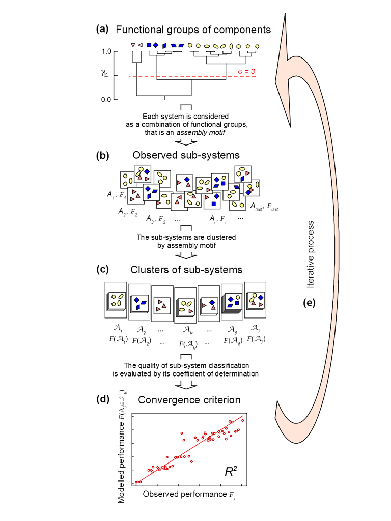

Method for clustering functionally redundant components: (a) Component clustering, (b) Identification of assembly motifs, (c) Classification of sub-systems by assembly motif, (d) Computation of convergence criterion, (e) Iterative ajustment of component clustering

- first, the **primary tree** that best accounts for the observed performance of component assemblages is fitted (Figure 1). This primary tree runs from a trunk, that is the trivial cluster where all components belonging to the system are clustered together, towards leaves where each component is isolated in a singleton. Each tree level corresponds to a clustering of compoenets in a given number of clusters, and the whole tree has therefore a deep equal to the number of components. Quality of clustering is evaluated by its residual sum of squares (*RSS*), that is its coefficient of determination (*R2* ) when divided by the total sum of squares (*TSS*), minus one. Trunk is under-fitted (*R2 = 0*) and leaves are over-fitted (*R2 = 1*): neither the first one nor the last ones are informative. The most informative component clustering is located between the trunk and the leaves.
- second, the **performance of each assemblage** is predicted by cross-validation using the primary tree. When all components belonging to the system are clustered together in a trivial large cluster, the performance of each assemblage can be predicted by cross-validation as the mean performance of all other assemblages. As the number of component clusters increases, the size of assembly motifs decreases, then the predictability of the performance of each assemblage also decreases until the assemblage is the sole representative of its assembly motif: then its performance can no longer be predicted by cross-validation. We consider the last prediction, *i.e.* the prediction based on a component clustering in a smaller number of clsuters, thus a less efficient model, as the best possible one for this assemblage. The procedure allows to get the best possible prediction for each component assemblage. The method of cross-validation is a leave-one-out when the size of assembly motifs is small, and optionally a jackknife method when the size of assembly motifs is larger.
- third, a **secondary tree** is extracted from the primary tree, by pruning it on the basis of its predictive ability and its parcimony. Each component clustering in a given number of clusters, *i.e.* each tree level, is a model: the model predictive ability is evaluated by cross-validation and the model parcimony is evaluated by the Akaike Informative Criterion (AIC). Then each component clustering along the tree is compared to each others for its predictive ability and its AIC: a component clustering that improves the model predictive ability and decreases the model AIC in regard to previous models is selected as a more efficient model. The most efficient model has, in the same time, the highest predictive ability and the lowest AIC. The size of the most efficient model defines the optimum number of component clusters. The secondary tree is the primary tree pruned above the optimum number of component clusters.

## Format of dataset

The dataset consists of a collection of different assemblages of components belonging to the system in consideration, of which the elemental composition is known, and one or several emergent, collective, system-specific performances are observed. The system in consideration is composed of all the components filled. Each assemblage can achieve several performances, for instance a same performance observed at different times or under different conditions (monitoring of biomass production over time or on various places), or performances of different natures for a multi-functional analysis.

The format of the dataset is as follows. On a first line: assemblage identity, a list of components identified by their names, a list of performances identified by their names. On following lines, a line by assemblage, name of the assemblage, a sequence of 0 (absence) and 1 (presence of component within the assemblage), a sequence of numeric values for each observed performances, over time, over places, or over performances of different natures.

Here, for instance, the famous experiment Biodiversity II done at Cedar Creek, University of Minnesota, USA, by David Tilman and his collaborators. The interactive system is a meadow, composed of 16 grassland species, observed on 91 plots over 3 years. The dataset includes 91 lines, a line by assemblage identified by *“Plot”*. The occurrence of 16 species (identifed as *“Achmi”*, *“Agrsm”*, *“Amocan”*, *“Andge”*, *“Asctu”*, *“Elyca”*, *“Koecr”*, *“Lesca”*, *“Liaas”*, *“Luppe”*, *“Monfi”*, *“Panvi”*, *“Petpu”*, *“Poapr”*, *“Schsc”* and *“Sornu”*) are noted by *“0”* (absent or *FALSE*) or *“1”* (present or *TRUE*). The assemblage performances are identified as *“y2004”*, *“y2005”* and *“y2006”*.

```r
library(functClust)

# production of biomass in 2004, 2005 and 2006 in Biodiversity II experiment
data(CedarCreek.2004.2006.dat)
dim(CedarCreek.2004.2006.dat)
```

```
#> [1] 91 20
```

```r
colnames(CedarCreek.2004.2006.dat)
```

```
#>  [1] "Plot"   "Achmi"  "Agrsm"  "Amocan" "Andge"  "Asctu"  "Elyca"
#>  [8] "Koecr"  "Lesca"  "Liaas"  "Luppe"  "Monfi"  "Panvi"  "Petpu"
#> [15] "Poapr"  "Schsc"  "Sornu"  "y2004"  "y2005"  "y2006"
```

```r
rownames(CedarCreek.2004.2006.dat)
```

```
#>  [1] "1"  "2"  "3"  "4"  "5"  "6"  "7"  "8"  "9"  "10" "11" "12" "13" "14"
#> [15] "15" "16" "17" "18" "19" "20" "21" "22" "23" "24" "25" "26" "27" "28"
#> [29] "29" "30" "31" "32" "33" "34" "35" "36" "37" "38" "39" "40" "41" "42"
#> [43] "43" "44" "45" "46" "47" "48" "49" "50" "51" "52" "53" "54" "55" "56"
#> [57] "57" "58" "59" "60" "61" "62" "63" "64" "65" "66" "67" "68" "69" "70"
#> [71] "71" "72" "73" "74" "75" "76" "77" "78" "79" "80" "81" "82" "83" "84"
#> [85] "85" "86" "87" "88" "89" "90" "91"
```

```r
# the data for each component assemblage
line <- 10
CedarCreek.2004.2006.dat[line, ]
```

```
#>    Plot Achmi Agrsm Amocan Andge Asctu Elyca Koecr Lesca Liaas Luppe Monfi
#> 10   24     0     0      0     0     1     1     0     0     0     0     0
#>    Panvi Petpu Poapr Schsc Sornu    y2004    y2005    y2006
#> 10     1     0     0     1     0 48.94467 54.86133 46.62233
```

## The main functions of *functClust*

The package *functClust* contains two groups of main functions. The first group includes 4 functions (*fclust*, *fclust_plot*, *fclust_write* and *fclust_read*) which allow a basic combinatorial analysis, its plotting and its saving.

- **fclust** does all computations. It fits a primary tree of component clustering to assemblage performances, extracts a secondary tree for its predicting ability and parcimony, predicts the performance of each assemblage using the whole secondary tree, then returns an object containing the results of the functional clustering of system components: primary and secondary trees of component clustering, modelled and predicted performances of component assemblages, composition and mean performances of assembly motifs.
- **fclust_plot** finalizes the findings. It takes the object generated by the function *fclust*, then plots numerous useful graphs for illustrating results and the ways by which they were obtained: primary and secondary trees of component clustering, composition and mean performances of assembly motifs, mean performances of assemblages containing a given components, observed, simulated and predicted performances of assemblages labelled by assembly motif, performances of some given assemblages, etc…
- **fclust_write** and **fclust_read** allow to save and load, respectively, the results of a functional clustering generated by the function *fclust*.

Both the functions *fclust* and *fclust_plot* are managed by a set of options.

The second group of functions also includes 4 functions (*ftest*, *ftest_plot*, *ftest_write* and *ftestread*) which allow to test the significance *(i)* of different components that belong to the interactive system, basic combinatorial analysis, *(ii)* of different assemblages that compose the dataset, *(iii)* of different observed performances if it is the case, and *(iv)* to evaluate the robustness of component clustering if several performances were observed.

- **ftest** does different computations depending on the options chosen. All tests are time-consumming, because they are based on repeated combinatorial analysis done on slightly modified datasets.
- **ftest_plot** plots numerous graphs for illustrating results.
- **ftest_write** and **ftest_read** allow to save and load, respectively, the results of testing.

All the functions are managed by a set of options. However, the package *functClust* shows all the functions used for analysing a dataset by a functional clustering and plot the results. Each function can be directly used for specific computation or plotting.

## Note

Note that some computations are time-consuming. To facilitate the monitoring of the smooth running of the computations, informations are written on the Console and graphs are drawn on the Plots panel. The writting are enable or disable by the “verbose” option.

```r
getOption("verbose")
```

```
#> [1] FALSE
```

```r
# to follow the computations
options(verbose = TRUE)
# to deactivate the option
options(verbose = FALSE)
```

## Availability and installation of *functClust*

The package *functClust* (version 0.1.0) is available on :

- **the gitlab** of Eco&Sols: https://gitlab.com/ecosols/functclust/ ,
- **the dataverse** of INRAE: https://data.inra.fr/privateurl.xhtml?token=348d7f33-0cf7-41cf-9516-c547846e9498 ,
- **the R-CRAN** soon after its submission: https://CRAN.R-project.org .

It can be load and install with:

```r
#install.packages("functClust")
```

## References

Jaillard, B., Richon, C., Deleporte, P., Loreau, M. and Violle, C. (2018) An a posteriori species clustering for quantifying the effects of species interactions on ecosystem functioning. *Methods in Ecology and Evolution, 9:704-715.* https://doi.org/10.1111/2041-210X.12920

Jaillard, B., Deleporte, P., Loreau, M. and Violle, C. (2018) A combinatorial analysis using observational data identifies species that govern ecosystem functioning. *PLoS ONE 13(8): e0201135.* https://doi.org/10.1371/journal.pone.0201135

Jaillard, B., Deleporte, P., Isbell, F., Loreau, M. and Violle, C. (submitted) Identifying plant functional groups that govern ecosystem functioning in a long-term biodiversity experiment.